# Analyses using TPSai (Study 2 and 3)

Author

Riccardo Volpato

```r
library(tidyverse)
library(knitr)
library(polycor)
library(semTools)
library(forcats)
```

# Data Processing

```r
options(readr.show_col_types = FALSE)
file_path <- "data/shared/TPSai+–+Prolific_CFA+Eval+Demog.csv"
raw_data  <- read_csv(file_path, n_max = 2)
colnames  <- names(raw_data)
q_text    <- setNames(sub(".* - ", "", as.character(raw_data[1, ])), colnames)
raw_data  <- read_csv(file_path, col_names = colnames, skip = 2)
```

```r
questions_map <- read_csv("surveys/cfa_qs.csv")
cols_tpsai_raw  <- sprintf("TPSAI_%d", seq_len(nrow(questions_map)))
```

```r
questions_map |> kable()
```

| ID | 2F | 3F | 4F | Item |
| --- | --- | --- | --- | --- |
| TPSAI_01 | Motivations | Motivations | Cognitive Trust | I trust the AI to provide me information that helps me manage my psychological challenges |
| TPSAI_02 | Motivations | Motivations | Cognitive Trust | I trust the AI to help me clarify my thoughts about a difficult situation |
| TPSAI_03 | Motivations | Motivations | Cognitive Trust | I trust that what the AI tells me about psychological concepts and processes is accurate and reliable |
| TPSAI_04 | Motivations | Motivations | Cognitive Trust | I can rely on the AI to make sense of the perspective of someone I am having difficulties to understand |
| TPSAI_05 | Motivations | Motivations | Cognitive Trust | Using the AI enables me to see how my experiences fit into what is common for others |
| TPSAI_06 | Motivations | Motivations | Cognitive Trust | I trust the AI to understand my specific needs when I ask for support |
| TPSAI_07 | Motivations | Motivations | Cognitive Trust | I trust the AI to give me advice that is well-tailored to my specific situation |
| TPSAI_08 | Motivations | Motivations | Cognitive Trust | I trust that the more information the AI has about me, the better it can support me |
| TPSAI_09 | Motivations | Motivations | Cognitive Trust | I trust the AI to reflect the feelings I share in a way that feels accurate |
| TPSAI_10 | Motivations | Motivations | Affective Trust | I trust the AI to make me feel heard and validated |
| TPSAI_11 | Motivations | Motivations | Affective Trust | I feel calmer when I talk to the AI while distressed |
| TPSAI_12 | Motivations | Motivations | Affective Trust | Talking to the AI about difficult situations leaves me feeling reassured |
| TPSAI_13 | Motivations | Motivations | Affective Trust | I trust that the AI responses do not make me feel discriminated |
| TPSAI_14 | Motivations | Motivations | Affective Trust | I trust the AI to provide me with a space where I can express myself freely |
| TPSAI_15 | Motivations | Motivations | Affective Trust | Opening up to the AI about personal concerns feels safe |
| TPSAI_16 | Concerns | Concerns | Concerns | I am concerned that the AI may not be able to respond appropriately to a mental health crisis (e.g., feeling hopeless, stuck, or wanting to self-harm) |
| TPSAI_17 | Concerns | Concerns | Concerns | I am concerned that the AI does not sufficiently highlight its limitations as a mental health tool |
| TPSAI_18 | Concerns | Concerns | Concerns | I believe the AI may provide inaccurate or misleading mental health information |
| TPSAI_19 | Concerns | Concerns | Concerns | I am concerned that the AI offers psychological advice without sufficient ethical and regulatory accountability |
| TPSAI_20 | Concerns | Concerns | Concerns | I am concerned that the AI company may use my data in ways I do not approve of |
| TPSAI_21 | Concerns | Concerns | Concerns | I am skeptical that the AI company ensures the AI is safe to use for mental health support |
| TPSAI_22 | Concerns | Concerns | Concerns | I am concerned that the values of the AI company do not sufficiently align with my own |
| TPSAI_23 | Concerns | Concerns | Concerns | I am concerned that the AI company treats my wellbeing as secondary to their commercial interests |
| TPSAI_24 | Concerns | Concerns | Concerns | I trust AI responses less as conversations get longer and the AI starts to ‘drift’ (e.g., speaks repetitively or less consistently) |
| TPSAI_25 | Concerns | Concerns | Concerns | I am concerned that the way the AI communicates may lead me to trust it more than I should |
| TPSAI_26 | Concerns | Relational Scepticism | Relational Scepticism | The AI cannot replace human support even when it is limited and difficult to access |
| TPSAI_27 | Concerns | Relational Scepticism | Relational Scepticism | Even though the AI sounds human, our interactions lack a sense of shared presence and experience |
| TPSAI_28 | Concerns | Relational Scepticism | Relational Scepticism | The emotional support the AI can offer is limited by its lack of embodied feelings and shared presence |
| TPSAI_29 | Concerns | Relational Scepticism | Relational Scepticism | While the AI uses empathic language, it does not comprehend and care about my experiences |
| TPSAI_30 | Concerns | Relational Scepticism | Relational Scepticism | Forming an emotional connection with the AI is limited by its lack of genuine feelings and experience |

```r
likert_levels <- c(
  "Strongly disagree"          = 1,
  "Disagree"                   = 2,
  "Somewhat disagree"          = 3,
  "Neither agree nor disagree" = 4,
  "Somewhat agree"             = 5,
  "Agree"                      = 6,
  "Strongly agree"             = 7
)

likert_levels_5 <- c(
  "Strongly disagree"          = 1,
  "Disagree"                   = 2,
  "Neither agree nor disagree" = 3,
  "Agree"                      = 4,
  "Strongly agree"             = 5
)

overall_levels <- c(
  "Not at all"  = 1,
  "Very little" = 2,
  "A little"    = 3,
  "Moderately"  = 4,
  "Quite a bit" = 5,
  "Very much"   = 6,
  "Completely"  = 7
)

freq_levels <- c(
  "Never",
  "About once a month",
  "About once a week to a few times a month",
  "Several times a week",
  "Daily or multiple times a day"
)
```

```r
cols_tpsai <- gsub("^TPSAI_(\\d)$", "TPSAI_0\\1", cols_tpsai_raw)
comp_items    <- sprintf("TPSAI_%02d", c(1:9))
affect_items  <- sprintf("TPSAI_%02d", c(10:15))
risk_items      <- sprintf("TPSAI_%02d", 16:25)
relScept_items      <- sprintf("TPSAI_%02d", 26:30)

item_map <- bind_rows(
  tibble(item = comp_items,   top = "Motivations",    sub = "Competence"),
  tibble(item = affect_items, top = "Motivations",    sub = "Affective"),
  tibble(item = risk_items,     top = "Concerns", sub = "RiskVigilance"),
  tibble(item = relScept_items,     top = "Concerns", sub = "RelationalScepticism")
) |>
  arrange(item)

item_map <- item_map |>
  mutate(sub3 = if_else(top == "Motivations", "Motivations", sub))

trust_items    <- item_map |> filter(top == "Motivations")    |> pull(item)
distrust_items <- item_map |> filter(top == "Concerns") |> pull(item)

item_map |> count(top, sub) |> kable(col.names = c("Top-level", "Subfactor", "Items"))
```

| Top-level | Subfactor | Items |
| --- | --- | --- |
| Concerns | RelationalScepticism | 5 |
| Concerns | RiskVigilance | 10 |
| Motivations | Affective | 6 |
| Motivations | Competence | 9 |

```r
ptt_items <- sprintf("PTT_%d", 1:6)
etmcq_items <- sprintf("ETMCQ_%d", 1:15)
gaid_items <- sprintf("GAID_%d", 1:11)

eval_data <- raw_data |>
  mutate(across(all_of(cols_tpsai_raw), ~ likert_levels[.x])) |>
  mutate(across(all_of(etmcq_items), ~ likert_levels[.x])) |>
  mutate(across(all_of(gaid_items), ~ likert_levels_5[.x])) |>
  mutate(across(all_of(ptt_items), ~ likert_levels_5[.x])) |>
  rename(all_of(setNames(cols_tpsai_raw, cols_tpsai))) |>
  mutate(
    motivations_score = rowMeans(across(all_of(trust_items))),
    concerns_score = rowMeans(across(all_of(risk_items))),
    rel_scept_score = rowMeans(across(all_of(relScept_items)))
  ) |>
  mutate(
    frequency_level = factor(FREQ, levels = freq_levels, ordered = TRUE),
    frequency_level = as.integer(frequency_level),
    trust_level   = overall_levels[TR],
    distrust_level   = overall_levels[DT]
  ) |>
  mutate(platform =
           coalesce(`PLAT-PSY_11_TEXT`, `PLAT-PSY`, `PLAT-GEN_11_TEXT`, `PLAT-GEN`)) |>
  select(
    all_of(cols_tpsai), motivations_score, concerns_score, rel_scept_score,
    frequency_level, trust_level, distrust_level,
    all_of(ptt_items), all_of(etmcq_items), all_of(gaid_items),
    `PSY-FREQ`, `PSY-SAT`, platform, Age)
```

# TPSai Items and Factors

```r
item_stats <- eval_data %>%
  select(all_of(cols_tpsai)) %>%
  pivot_longer(everything(), names_to = "item", values_to = "response") %>%
  group_by(item) %>%
  summarise(
    n        = sum(!is.na(response)),
    mean     = mean(response, na.rm = TRUE),
    sd       = sd(response, na.rm = TRUE),
    median   = median(response, na.rm = TRUE),
    min      = suppressWarnings(min(response, na.rm = TRUE)),
    max      = suppressWarnings(max(response, na.rm = TRUE)),
    skew     = psych::skew(response, na.rm = TRUE),
    kurtosis = psych::kurtosi(response, na.rm = TRUE),
    .groups  = "drop"
  ) %>%
  arrange(item)

item_stats %>%
  knitr::kable(
    digits = 2,
    col.names = c("Item", "N", "Mean", "SD",
                  "Median", "Min", "Max", "Skew", "Kurtosis"),
  )
```

| Item | N | Mean | SD | Median | Min | Max | Skew | Kurtosis |
| --- | --- | --- | --- | --- | --- | --- | --- | --- |
| TPSAI_01 | 401 | 4.09 | 1.62 | 5 | 1 | 7 | -0.49 | -0.86 |
| TPSAI_02 | 401 | 4.52 | 1.61 | 5 | 1 | 7 | -0.65 | -0.50 |
| TPSAI_03 | 401 | 4.17 | 1.58 | 5 | 1 | 7 | -0.43 | -0.69 |
| TPSAI_04 | 401 | 4.16 | 1.61 | 5 | 1 | 7 | -0.49 | -0.68 |
| TPSAI_05 | 401 | 4.41 | 1.52 | 5 | 1 | 7 | -0.66 | -0.26 |
| TPSAI_06 | 401 | 3.96 | 1.70 | 4 | 1 | 7 | -0.28 | -1.10 |
| TPSAI_07 | 401 | 4.27 | 1.65 | 5 | 1 | 7 | -0.49 | -0.67 |
| TPSAI_08 | 401 | 4.41 | 1.57 | 5 | 1 | 7 | -0.57 | -0.42 |
| TPSAI_09 | 401 | 4.02 | 1.62 | 4 | 1 | 7 | -0.46 | -0.86 |
| TPSAI_10 | 401 | 4.22 | 1.72 | 5 | 1 | 7 | -0.43 | -0.85 |
| TPSAI_11 | 401 | 3.84 | 1.73 | 4 | 1 | 7 | -0.26 | -1.05 |
| TPSAI_12 | 401 | 4.06 | 1.71 | 4 | 1 | 7 | -0.33 | -0.92 |
| TPSAI_13 | 401 | 5.00 | 1.33 | 5 | 1 | 7 | -0.82 | 0.75 |
| TPSAI_14 | 401 | 4.81 | 1.57 | 5 | 1 | 7 | -0.89 | 0.21 |
| TPSAI_15 | 401 | 3.93 | 1.79 | 4 | 1 | 7 | -0.22 | -1.13 |
| TPSAI_16 | 401 | 5.31 | 1.58 | 6 | 1 | 7 | -0.86 | -0.04 |
| TPSAI_17 | 401 | 5.16 | 1.69 | 6 | 1 | 7 | -0.78 | -0.34 |
| TPSAI_18 | 401 | 5.01 | 1.57 | 5 | 1 | 7 | -0.58 | -0.45 |
| TPSAI_19 | 401 | 5.27 | 1.63 | 6 | 1 | 7 | -0.80 | -0.26 |
| TPSAI_20 | 401 | 5.38 | 1.66 | 6 | 1 | 7 | -0.99 | 0.14 |
| TPSAI_21 | 401 | 5.16 | 1.64 | 6 | 1 | 7 | -0.74 | -0.26 |
| TPSAI_22 | 401 | 5.01 | 1.68 | 5 | 1 | 7 | -0.58 | -0.54 |
| TPSAI_23 | 401 | 5.09 | 1.65 | 5 | 1 | 7 | -0.63 | -0.41 |
| TPSAI_24 | 401 | 5.04 | 1.51 | 5 | 1 | 7 | -0.76 | 0.00 |
| TPSAI_25 | 401 | 4.48 | 1.76 | 5 | 1 | 7 | -0.44 | -0.86 |
| TPSAI_26 | 401 | 5.76 | 1.41 | 6 | 1 | 7 | -1.07 | 0.37 |
| TPSAI_27 | 401 | 5.70 | 1.40 | 6 | 1 | 7 | -1.22 | 1.09 |
| TPSAI_28 | 401 | 5.70 | 1.27 | 6 | 2 | 7 | -0.99 | 0.51 |
| TPSAI_29 | 401 | 5.63 | 1.48 | 6 | 1 | 7 | -0.95 | -0.03 |
| TPSAI_30 | 401 | 5.66 | 1.39 | 6 | 1 | 7 | -1.07 | 0.61 |

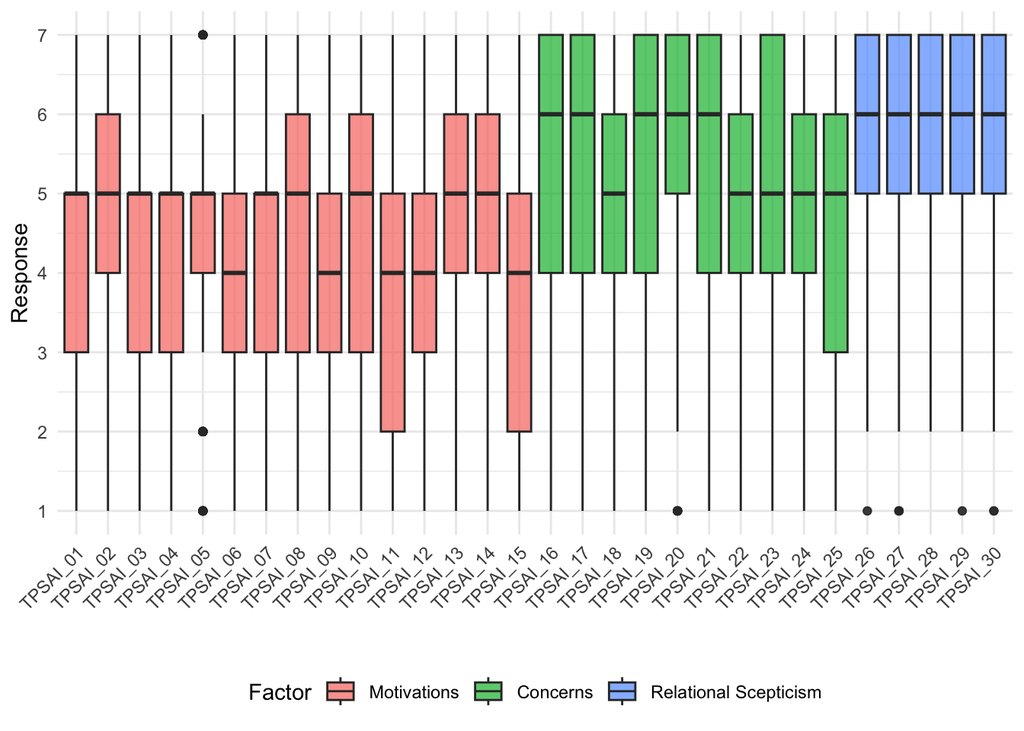

```r
eval_data |>
  select(all_of(cols_tpsai)) |>
  pivot_longer(everything(), names_to = "item", values_to = "response") |>
  mutate(
    factor = case_when(
      item %in% trust_items ~ "Motivations",
      item %in% risk_items ~ "Concerns",
      item %in% relScept_items ~ "Relational Scepticism",
      .default = NA_character_
    )
  ) |>
  mutate(factor = factor(factor, levels = c("Motivations", "Concerns", "Relational Scepticism"))) |>
  ggplot(aes(x = item, y = response, fill = factor)) +
  geom_boxplot(alpha = 0.7) +
  scale_y_continuous(limits = c(1, 7), breaks = 1:7) +
  labs(x = "", y = "Response", fill = "Factor") +
  theme_minimal() +
  theme(
    axis.text.x = element_text(angle = 45, hjust = 1),
    legend.position = "bottom"
  )
```

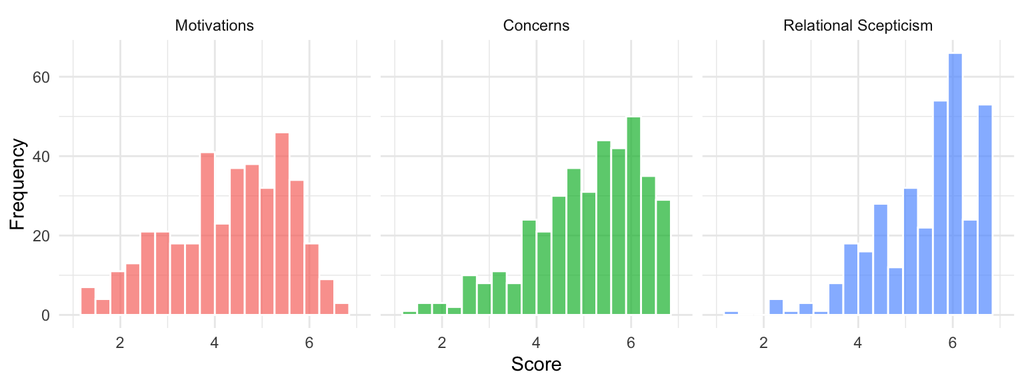

```r
eval_data |>
  pivot_longer(
    cols = c(motivations_score, concerns_score, rel_scept_score),
    names_to = "factor",
    values_to = "score"
  ) |>
  mutate(
    factor = factor(
      factor,
      levels = c("motivations_score", "concerns_score", "rel_scept_score"),
      labels = c("Motivations", "Concerns", "Relational Scepticism")
    )
  ) |>
  ggplot(aes(x = score, fill = factor)) +
  geom_histogram(bins = 20, alpha = 0.7, color = "white") +
  facet_wrap(~factor, ncol = 3) +
  scale_x_continuous(limits = c(1, 7)) +
  labs(x = "Score", y = "Frequency", fill = "") +
  theme_minimal() +
  theme(legend.position = "none")
```

**Inter-factor correlations**

```r
factors_data <- eval_data |>
  select(
    motivations_score, concerns_score, rel_scept_score
  )

cor(factors_data)
```

```
                  motivations_score concerns_score rel_scept_score
motivations_score         1.0000000     -0.5717660      -0.5468003
concerns_score           -0.5717660      1.0000000       0.7270383
rel_scept_score          -0.5468003      0.7270383       1.0000000
```

# Study 2: Scale Comparisons

Throughout this analysis we estimate correlations using `polycor::hetcor()`, which selects the appropriate coefficient for each pair of variables — Pearson for two continuous variables, polyserial for a continuous and an ordinal variable, and polychoric for two ordinal variables — so that correlations involving single-item ordinal measures are not attenuated by treating ordered categories as interval scores.

## Single-item Trust/Distrust

In our questionnaire, we asked respondents to answer two single-item Trust and Distrust questions. Let’s look at the correlations between factors and subfactors with answers to these questions.

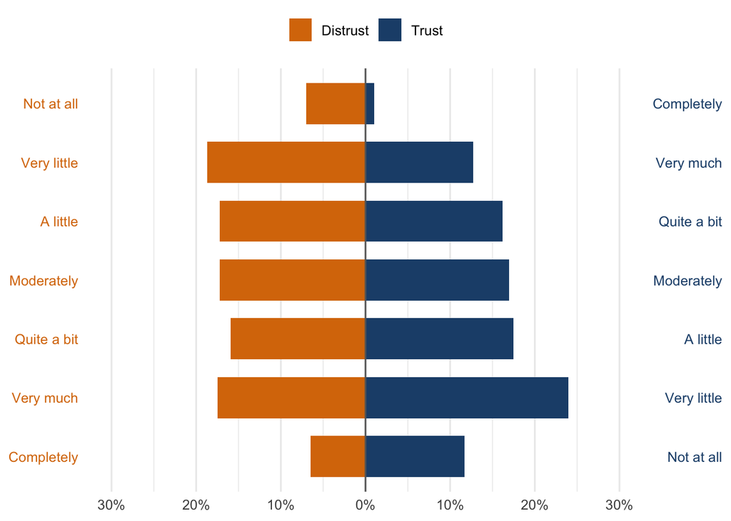

```r
overall_labels <- c("Not at all", "Very little", "A little", "Moderately",
                    "Quite a bit", "Very much", "Completely")

trust_recode <- setNames(overall_labels, rev(overall_labels))

plot_data_div <- raw_data %>%
  select(TR, DT) %>%
  mutate(TR = unname(trust_recode[TR])) %>%
  pivot_longer(cols = c(TR, DT), names_to = "measure", values_to = "response") %>%
  mutate(
    response = factor(response, levels = overall_labels),
    measure  = factor(measure, levels = c("DT", "TR"),
                      labels = c("Distrust", "Trust"))
  ) %>%
  count(measure, response, .drop = FALSE) %>%
  group_by(measure) %>%
  mutate(
    pct = n / sum(n),
    pct_signed = if_else(measure == "Distrust", -pct, pct)
  ) %>%
  ungroup()

overalls_plot <- ggplot(plot_data_div, aes(x = pct_signed, y = response, fill = measure)) +
  geom_col(width = 0.7) +
  geom_vline(xintercept = 0, color = "grey40") +
  scale_x_continuous(
    labels = function(x) scales::percent(abs(x), accuracy = 1),
    limits = c(-0.30, 0.30),
    breaks = seq(-0.30, 0.30, 0.10)
  ) +
  scale_y_discrete(
    limits = rev,
    sec.axis = dup_axis(labels = overall_labels)
  ) +
  scale_fill_manual(values = c("Trust" = "#1f4e79", "Distrust" = "#d97706")) +
  labs(x = NULL, y = NULL, fill = NULL) +
  theme_minimal(base_size = 12) +
  theme(
    legend.position = "top",
    panel.grid.major.y = element_blank(),
    axis.text.y.left   = element_text(color = "#d97706"),
    axis.text.y.right  = element_text(color = "#1f4e79")
  )

overalls_plot
```

*Pre-registration:* we are expecting moderate to high correlation values (0.4 to 0.8), indicating that scale scores are predictive of single-item trust and distrust question. More specifically we are expecting high positive correlations (0.6 to 0.8) between corresponding scores and single items (e.g. trust scores and trust single item) and moderate negative correlations (-0.6 to -0.4) between non-complementary pairs (e.g. trust scores and distrust single items), since we assume that trust and distrust are related but not the polar opposite of each other.

```r
single_items_data <- eval_data |>
  transmute(
    motivations_score, concerns_score, rel_scept_score,
    trust_level    = ordered(trust_level,    levels = 1:7),
    distrust_level = ordered(distrust_level, levels = 1:7)
  ) |>
  as.data.frame()

single_items_cors <- hetcor(single_items_data, ML = TRUE, std.err = TRUE)
```

```r
single_items_cors$correlations |>
  as.data.frame() |>
  select(trust_level, distrust_level) |>
  kable(digits = 2)
```

|  | trust_level | distrust_level |
| --- | --- | --- |
| motivations_score | 0.82 | -0.49 |
| concerns_score | -0.60 | 0.50 |
| rel_scept_score | -0.57 | 0.38 |
| trust_level | 1.00 | -0.57 |
| distrust_level | -0.57 | 1.00 |

```r
single_items_cors$type |>
  as.data.frame() |>
  select(V4, V5) |>
  kable()
```

| V4 | V5 |
| --- | --- |
| Polyserial | Polyserial |
| Polyserial | Polyserial |
| Polyserial | Polyserial |
|  | Polychoric |
| Polychoric |  |

```r
single_items_tpsai_data <- eval_data |>
  select(
    all_of(cols_tpsai),
    trust_level,
    distrust_level) |>
  mutate(
    trust_level    = ordered(trust_level,    levels = 1:7),
    distrust_level = ordered(distrust_level, levels = 1:7)
  ) |>
  as.data.frame()

single_items_tpsai_cors <- hetcor(single_items_tpsai_data, ML = TRUE, std.err = TRUE)
```

```r
single_items_tpsai_cors$correlations |>
  as.data.frame() |>
  select(trust_level, distrust_level) |>
  filter(abs(distrust_level) > 0.4) |>
  kable(digits = 2)
```

|  | trust_level | distrust_level |
| --- | --- | --- |
| TPSAI_01 | 0.75 | -0.47 |
| TPSAI_02 | 0.69 | -0.41 |
| TPSAI_04 | 0.67 | -0.40 |
| TPSAI_06 | 0.71 | -0.42 |
| TPSAI_07 | 0.69 | -0.44 |
| TPSAI_09 | 0.68 | -0.43 |
| TPSAI_12 | 0.73 | -0.40 |
| TPSAI_15 | 0.69 | -0.43 |
| TPSAI_17 | -0.51 | 0.41 |
| TPSAI_18 | -0.56 | 0.46 |
| TPSAI_19 | -0.53 | 0.43 |
| TPSAI_21 | -0.54 | 0.41 |
| TPSAI_22 | -0.53 | 0.45 |
| TPSAI_23 | -0.46 | 0.43 |
| trust_level | 1.00 | -0.57 |
| distrust_level | -0.57 | 1.00 |

### Single-item test-retest

```r
retest_file_path <- "data/shared/TPSai+-+Prolific_Retest.csv"
raw_retest_data  <- read_csv(retest_file_path, n_max = 2)
retest_colnames  <- names(raw_retest_data)
raw_retest_data  <- read_csv(retest_file_path, col_names = retest_colnames, skip = 2)
```

```r
retest_data <- raw_retest_data |>
  mutate(
    trust_level   = overall_levels[TR],
    distrust_level   = overall_levels[DT],
    trust_level_t2   = overall_levels[TR_t2],
    distrust_level_t2   = overall_levels[DT_t2]
  ) |>
  select(
    trust_level, distrust_level,
    trust_level_t2, distrust_level_t2
  )
```

```r
si_retest_data <- retest_data |>
  transmute(
    trust_level    = ordered(trust_level,    levels = 1:7),
    trust_level_t2    = ordered(trust_level_t2,    levels = 1:7),
    distrust_level = ordered(distrust_level, levels = 1:7),
    distrust_level_t2 = ordered(distrust_level_t2, levels = 1:7)
  ) |>
  as.data.frame()

si_retest_cors <- hetcor(si_retest_data, ML = TRUE, std.err = TRUE)
```

```r
si_retest_cors$correlations |> kable(digits = 3)
```

|  | trust_level | trust_level_t2 | distrust_level | distrust_level_t2 |
| --- | --- | --- | --- | --- |
| trust_level | 1.000 | 0.835 | -0.640 | -0.503 |
| trust_level_t2 | 0.835 | 1.000 | -0.539 | -0.536 |
| distrust_level | -0.640 | -0.539 | 1.000 | 0.505 |
| distrust_level_t2 | -0.503 | -0.536 | 0.505 | 1.000 |

```r
si_retest_cors$type
```

```
     [,1]         [,2]         [,3]         [,4]
[1,] ""           "Polychoric" "Polychoric" "Polychoric"
[2,] "Polychoric" ""           "Polychoric" "Polychoric"
[3,] "Polychoric" "Polychoric" ""           "Polychoric"
[4,] "Polychoric" "Polychoric" "Polychoric" ""
```

## Related scales

We seek to confirm that TPSai is related yet substantially different from measures of other related constructs including:

1. Predisposition to Trust in Automated Technology (PTT-A)
2. Epistemic Trust, Mistrust, and Credulity Questionnaire (ETMCQ) towards unknown others
3. Generative AI dependency (GAID)

### PTT-A

Ragone et al. (2026) used and adapted the PTT scale from Merritt et al. (2013), swapped “machines” for “computers” and making some other minor modifications. However, we decided to use the PTT-A scale from Scholz et al. (2025) which was developed more recently and was evaluated through more rigorous psychometric analysis, including test-retest reliability.

We use the PTT-A short form (Scholz et al. 2025) which comprises of the following six **items**:

1. Even though I may sometimes suffer the consequences of trusting automated technological systems, I still prefer to trust than not to trust them.
2. I rarely trust automated technological systems because I can’t handle the uncertainty.
3. Automated technological systems are competent.
4. I am wary about the capabilities of automated technological systems.
5. I don’t expect that automated technological systems are willing to assist and support people.
6. I feel that automated technological systems can be relied upon to do what they say they will do.

**Scoring:** items are measured on a five-point Likert-type scale ranging from 1 (“strongly disagree”) to 5 (“strongly agree”) and items 2, 4, and 5 are reversed items (which we recode as recode as 6 − x). Given the briefness of the scale and its unidimensional nature we only compute the overall PTT-A score as the mean of its 6 items (after reversals).

### ETMCQ

**Factors:**

1. *Trust* - “individual is selectively and appropriately open to opportunities for social learning in the context of relationships”
2. *Mistrust* - “tendency to treat any source of information as unreliable or ill-intentioned, and to err on the side of rejecting or avoiding allowing oneself to be influenced by communication from others”
3. *Credulity* - “a pronounced lack of vigilance and discrimination, signalling a general lack of clarity about one’s own position and resulting in vulnerability to misinformation and potential risk of exploitation.”

**Items:**

| ID | Item | Factor |
| --- | --- | --- |
| ETMCQ_1 | I usually ask people for advice when I have a personal problem. | Trust |
| ETMCQ_2 | I find information easier to trust and absorb when it comes from someone who knows me well. | Trust |
| ETMCQ_3 | I’d prefer to find things out for myself on the internet rather than asking people for information. | Mistrust |
| ETMCQ_4 | I often feel that people do not understand what I want and need. | Mistrust |
| ETMCQ_5 | I am often considered naïve because I believe almost anything that people tell me. | Credulity |
| ETMCQ_6 | When I speak to different people, I find myself easily persuaded by what they say even if this is different from what I believed before. | Credulity |
| ETMCQ_7 | Sometimes, having a conversation with people who have known me for a long time helps me develop new perspectives about myself. | Trust |
| ETMCQ_8 | I find it very useful to learn from what people tell me about their experiences. | Trust |
| ETMCQ_9 | If you put too much faith in what people tell you, you are likely to get hurt. | Mistrust |
| ETMCQ_10 | When someone tells me something, my immediate reaction is to wonder why they are telling me this. | Mistrust |
| ETMCQ_11 | I have too often taken advice from the wrong people. | Credulity |
| ETMCQ_12 | People have told me that I am too easily influenced by others | Credulity |
| ETMCQ_13 | If I don’t know what to do, my first instinct is to ask someone whose opinion I value. | Trust |
| ETMCQ_14 | I don’t usually act on advice that I get from others even when I think it’s probably sound. | Mistrust |
| ETMCQ_15 | In the past, I have misjudged who to believe and been taken advantage of. | Credulity |

**Scoring:** items are 7-point Likert scales. Original paper (Campbell et al. 2021) is not clear about scoring, but no items seems reversed and factor scores are mean of the items in the factor. Mistrust had weak internal consistency in the original Study 2 (α = .65) s worth checking your own alphas before leaning on it. Given the clear 3-factors nature of ETMCQ we only compute factor scores (i.e. Trust, Mistrust, and Credulity) and no overall score.

**Assumed relationship with TPSai**

- Motivations should positively relate with Trust
- Mistrust should positively relate with Concerns and Relational Scepticism
- Credulity should negatively positively with Concerns

### GAID

**Factors:**

1. Cognitive preoccupation - “a persistent mental engagement with generative AI, characterized by anticipatory excitement, internal urges to use, and the increasing influence of AI on everyday decision-making”
2. Negative consequences - “self-reported concerns related to reliance on generative AI, including perceptions of reduced performance and diminished self-efficacy”
3. Withdrawal - “psychological distress and affective discomfort experienced when access to generative AI is restricted”

**Items:**

| ID | Item | Factor |
| --- | --- | --- |
| GAID_1 | My decisions are often influenced by generative AI. | Cognitive Preoccupation |
| GAID_2 | I feel an urge to use generative AI, even when it may not be necessary. | Cognitive Preoccupation |
| GAID_3 | I look forward to using generative AI, even if it is unrelated to the task at hand. | Cognitive Preoccupation |
| GAID_4 | My use of generative AI has caused concerns for me. | Negative Consequences |
| GAID_5 | I have trouble completing work or other responsibilities without generative AI. | Negative Consequences |
| GAID_6 | I feel less confident in my abilities without generative AI. | Negative Consequences |
| GAID_7 | My use of generative AI has negatively affected my problem-solving skills or efficiency. | Negative Consequences |
| GAID_8 | I experience restlessness if I am unable to use generative AI. | Withdrawal |
| GAID_9 | I feel unsettled or distracted when I cannot use generative AI. | Withdrawal |
| GAID_10 | I feel a sense of disconnection when I cannot access generative AI. | Withdrawal |
| GAID_11 | I get frustrated or irritable when I am unable to use generative AI. | Withdrawal |

**Scoring**: items are 5-point Likert scales. Factor scores are computed as mean of item ratings and overall scale score is computed as a mean of factor scores.

**Assumed relationship with TPSai:**

- Overall dependency should positively relate with Motivations and negatively with Concerns
- Negative consequences should positively relate with Concerns and Relational Scepticism
- Cognitive Preoccupation should positive relate with Concerns
- Withdrawal should negatively relate with Relational Scepticism

## Scale correlations

```r
instrument_map <- bind_rows(
  item_map |> transmute(item, factor = sub3, instrument = "TPSai"),

  tibble(
    instrument = "PTT",
    factor     = "PTT",
    item       = sprintf("PTT_%d", 1:6)
  ),

  tibble(
    instrument = "ETMCQ",
    item       = sprintf("ETMCQ_%d", 1:15),
    factor     = c("ETMCQ_Trust", "ETMCQ_Trust", "ETMCQ_Mistrust",
                   "ETMCQ_Mistrust", "ETMCQ_Credulity", "ETMCQ_Credulity",
                   "ETMCQ_Trust", "ETMCQ_Trust", "ETMCQ_Mistrust",
                   "ETMCQ_Mistrust", "ETMCQ_Credulity", "ETMCQ_Credulity",
                   "ETMCQ_Trust", "ETMCQ_Mistrust", "ETMCQ_Credulity")
  ),

  tibble(
    instrument = "GAID",
    item       = sprintf("GAID_%d", 1:11),
    factor     = rep(c("GAID_CogPre", "GAID_NegCons", "GAID_Withdrawal"),
                     times = c(3, 4, 4))
  )
)
```

### Correlations

Scale scores for the comparison instruments are computed as the mean of their constituent items, following the scoring procedures specified by the original authors. PTT-A items 2, 4, and 5 are reverse-coded as 6 − x prior to scoring; no items are reversed in the ETMCQ or the generative AI dependency scale. For the ETMCQ and the dependency scale we compute factor scores only, given their established multidimensional structure, with an additional overall dependency score as the mean of its three factor scores; for the PTT-A short form we compute a single score, given its unidimensional nature.

```r
# reverse-code PTT-A items 2, 4, 5 BEFORE scoring
eval_data <- eval_data |>
  mutate(across(all_of(sprintf("PTT_%d", c(2, 4, 5))), ~ 6 - .x))

score_factors <- function(data, map) {
  map |>
    group_by(factor) |>
    group_map(\(g, k) tibble(!!k$factor := rowMeans(data[g$item]))) |>
    bind_cols()
}

comparison_scores <- score_factors(eval_data, filter(instrument_map, instrument != "TPSai"))

# GAID overall = mean of its three factor scores (per Goh et al.)
comparison_scores <- comparison_scores |>
  mutate(GAID_Overall = rowMeans(across(starts_with("GAID_"))))

sec3 <- eval_data |>
  select(motivations_score, concerns_score, rel_scept_score) |>
  bind_cols(comparison_scores)
```

Correlations with TPSai scale scores are estimated with Pearson coefficients. Unlike the concurrent validity analyses, no polyserial or polychoric estimation is required here, as both sides of each correlation are multi-item composites with approximately continuous distributions rather than single ordinal items.

```r
tpsai_cols <- c("motivations_score", "concerns_score", "rel_scept_score")
other_cols <- setdiff(names(sec3), tpsai_cols)

ct <- psych::corr.test(sec3, adjust = "none")

sec3_raw <- expand_grid(tpsai = tpsai_cols, other = other_cols) |>
  mutate(
    r = map2_dbl(tpsai, other, \(a, b) ct$r[a, b]),
    CI = sprintf("[%.2f, %.2f]",
                 map2_dbl(tpsai, other,
                          \(a, b) tanh(atanh(ct$r[a, b]) - 1.96 / sqrt(nrow(sec3) - 3))),
                 map2_dbl(tpsai, other,
                          \(a, b) tanh(atanh(ct$r[a, b]) + 1.96 / sqrt(nrow(sec3) - 3)))
                 )
    ) |>
  arrange(other)
```

```r
sec3_raw |> kable(digits = 2)
```

| tpsai | other | r | CI |
| --- | --- | --- | --- |
| motivations_score | ETMCQ_Credulity | 0.22 | [0.12, 0.31] |
| concerns_score | ETMCQ_Credulity | 0.03 | [-0.07, 0.12] |
| rel_scept_score | ETMCQ_Credulity | -0.18 | [-0.27, -0.08] |
| motivations_score | ETMCQ_Mistrust | 0.15 | [0.05, 0.24] |
| concerns_score | ETMCQ_Mistrust | 0.09 | [-0.01, 0.19] |
| rel_scept_score | ETMCQ_Mistrust | -0.06 | [-0.15, 0.04] |
| motivations_score | ETMCQ_Trust | 0.13 | [0.03, 0.22] |
| concerns_score | ETMCQ_Trust | 0.00 | [-0.10, 0.10] |
| rel_scept_score | ETMCQ_Trust | -0.02 | [-0.11, 0.08] |
| motivations_score | GAID_CogPre | 0.59 | [0.52, 0.65] |
| concerns_score | GAID_CogPre | -0.35 | [-0.44, -0.27] |
| rel_scept_score | GAID_CogPre | -0.43 | [-0.50, -0.34] |
| motivations_score | GAID_NegCons | 0.30 | [0.21, 0.39] |
| concerns_score | GAID_NegCons | -0.02 | [-0.12, 0.08] |
| rel_scept_score | GAID_NegCons | -0.14 | [-0.24, -0.05] |
| motivations_score | GAID_Overall | 0.51 | [0.43, 0.58] |
| concerns_score | GAID_Overall | -0.24 | [-0.33, -0.15] |
| rel_scept_score | GAID_Overall | -0.37 | [-0.45, -0.28] |
| motivations_score | GAID_Withdrawal | 0.41 | [0.33, 0.49] |
| concerns_score | GAID_Withdrawal | -0.25 | [-0.34, -0.15] |
| rel_scept_score | GAID_Withdrawal | -0.39 | [-0.47, -0.31] |
| motivations_score | PTT | 0.51 | [0.44, 0.58] |
| concerns_score | PTT | -0.54 | [-0.61, -0.47] |
| rel_scept_score | PTT | -0.38 | [-0.46, -0.30] |

### Disattenuation by sample reliability

```r
omega_for <- function(data, map, fname) {
  items <- filter(map, factor == fname)$item
  fit <- cfa(paste0(fname, " =~ ", paste(items, collapse = " + ")),
             data = data, ordered = items, estimator = "WLSMV")
  semTools::compRelSEM(fit, tau.eq = FALSE, ord.scale = TRUE)[[1]]
}

omegas <- c(
  motivations_score = 0.96, concerns_score = 0.912, rel_scept_score = 0.859,  # ω from CFA (m3)
  map_dbl(setdiff(other_cols, "GAID_Overall"),
          \(f) omega_for(eval_data, instrument_map, f)) |>
    setNames(setdiff(other_cols, "GAID_Overall"))
)

sec3_raw <- sec3_raw |>
  mutate(
    omega_tpsai = omegas[tpsai],
    omega_other = omegas[other],
    r_dis       = r / sqrt(omega_tpsai * omega_other)
  )
```

```r
sec3_raw |> kable(digits = 2)
```

| tpsai | other | r | CI | omega_tpsai | omega_other | r_dis |
| --- | --- | --- | --- | --- | --- | --- |
| motivations_score | ETMCQ_Credulity | 0.22 | [0.12, 0.31] | 0.96 | 0.84 | 0.24 |
| concerns_score | ETMCQ_Credulity | 0.03 | [-0.07, 0.12] | 0.91 | 0.84 | 0.03 |
| rel_scept_score | ETMCQ_Credulity | -0.18 | [-0.27, -0.08] | 0.86 | 0.84 | -0.21 |
| motivations_score | ETMCQ_Mistrust | 0.15 | [0.05, 0.24] | 0.96 | 0.69 | 0.18 |
| concerns_score | ETMCQ_Mistrust | 0.09 | [-0.01, 0.19] | 0.91 | 0.69 | 0.11 |
| rel_scept_score | ETMCQ_Mistrust | -0.06 | [-0.15, 0.04] | 0.86 | 0.69 | -0.08 |
| motivations_score | ETMCQ_Trust | 0.13 | [0.03, 0.22] | 0.96 | 0.79 | 0.15 |
| concerns_score | ETMCQ_Trust | 0.00 | [-0.10, 0.10] | 0.91 | 0.79 | 0.00 |
| rel_scept_score | ETMCQ_Trust | -0.02 | [-0.11, 0.08] | 0.86 | 0.79 | -0.02 |
| motivations_score | GAID_CogPre | 0.59 | [0.52, 0.65] | 0.96 | 0.80 | 0.67 |
| concerns_score | GAID_CogPre | -0.35 | [-0.44, -0.27] | 0.91 | 0.80 | -0.41 |
| rel_scept_score | GAID_CogPre | -0.43 | [-0.50, -0.34] | 0.86 | 0.80 | -0.51 |
| motivations_score | GAID_NegCons | 0.30 | [0.21, 0.39] | 0.96 | 0.85 | 0.33 |
| concerns_score | GAID_NegCons | -0.02 | [-0.12, 0.08] | 0.91 | 0.85 | -0.02 |
| rel_scept_score | GAID_NegCons | -0.14 | [-0.24, -0.05] | 0.86 | 0.85 | -0.17 |
| motivations_score | GAID_Overall | 0.51 | [0.43, 0.58] | 0.96 | NA | NA |
| concerns_score | GAID_Overall | -0.24 | [-0.33, -0.15] | 0.91 | NA | NA |
| rel_scept_score | GAID_Overall | -0.37 | [-0.45, -0.28] | 0.86 | NA | NA |
| motivations_score | GAID_Withdrawal | 0.41 | [0.33, 0.49] | 0.96 | 0.92 | 0.44 |
| concerns_score | GAID_Withdrawal | -0.25 | [-0.34, -0.15] | 0.91 | 0.92 | -0.27 |
| rel_scept_score | GAID_Withdrawal | -0.39 | [-0.47, -0.31] | 0.86 | 0.92 | -0.44 |
| motivations_score | PTT | 0.51 | [0.44, 0.58] | 0.96 | 0.83 | 0.58 |
| concerns_score | PTT | -0.54 | [-0.61, -0.47] | 0.91 | 0.83 | -0.62 |
| rel_scept_score | PTT | -0.38 | [-0.46, -0.30] | 0.86 | 0.83 | -0.45 |

### Correlations between scales and single-items

```r
si_compare <- eval_data |>
  select(
    trust_level, distrust_level) |>
  transmute(
    trust_level    = ordered(trust_level,    levels = 1:7),
    distrust_level = ordered(distrust_level, levels = 1:7)
  ) |>
  bind_cols(comparison_scores) |>
  as.data.frame()

si_compare_cors <- hetcor(si_compare, ML = TRUE, std.err = TRUE)
```

```r
si_compare_cors$correlations |> kable(digits = 3)
```

|  | trust_level | distrust_level | ETMCQ_Credulity | ETMCQ_Mistrust | ETMCQ_Trust | GAID_CogPre | GAID_NegCons | GAID_Withdrawal | PTT | GAID_Overall |
| --- | --- | --- | --- | --- | --- | --- | --- | --- | --- | --- |
| trust_level | 1.000 | -0.565 | 0.213 | 0.125 | 0.094 | 0.560 | 0.307 | 0.468 | 0.476 | 0.515 |
| distrust_level | -0.565 | 1.000 | -0.023 | 0.056 | -0.038 | -0.288 | -0.070 | -0.139 | -0.361 | -0.198 |
| ETMCQ_Credulity | 0.213 | -0.023 | 1.000 | 0.382 | 0.171 | 0.304 | 0.397 | 0.367 | -0.031 | 0.402 |
| ETMCQ_Mistrust | 0.125 | 0.056 | 0.382 | 1.000 | -0.263 | 0.200 | 0.250 | 0.219 | -0.069 | 0.253 |
| ETMCQ_Trust | 0.094 | -0.038 | 0.171 | -0.263 | 1.000 | 0.012 | -0.004 | 0.000 | 0.065 | 0.004 |
| GAID_CogPre | 0.560 | -0.288 | 0.304 | 0.200 | 0.012 | 1.000 | 0.602 | 0.677 | 0.346 | 0.885 |
| GAID_NegCons | 0.307 | -0.070 | 0.397 | 0.250 | -0.004 | 0.602 | 1.000 | 0.682 | 0.059 | 0.859 |
| GAID_Withdrawal | 0.468 | -0.139 | 0.367 | 0.219 | 0.000 | 0.677 | 0.682 | 1.000 | 0.193 | 0.885 |
| PTT | 0.476 | -0.361 | -0.031 | -0.069 | 0.065 | 0.346 | 0.059 | 0.193 | 1.000 | 0.238 |
| GAID_Overall | 0.515 | -0.198 | 0.402 | 0.253 | 0.004 | 0.885 | 0.859 | 0.885 | 0.238 | 1.000 |

```r
si_compare_cors$type
```

```
      [,1]         [,2]         [,3]         [,4]         [,5]
 [1,] ""           "Polychoric" "Polyserial" "Polyserial" "Polyserial"
 [2,] "Polychoric" ""           "Polyserial" "Polyserial" "Polyserial"
 [3,] "Polyserial" "Polyserial" ""           "Pearson"    "Pearson"
 [4,] "Polyserial" "Polyserial" "Pearson"    ""           "Pearson"
 [5,] "Polyserial" "Polyserial" "Pearson"    "Pearson"    ""
 [6,] "Polyserial" "Polyserial" "Pearson"    "Pearson"    "Pearson"
 [7,] "Polyserial" "Polyserial" "Pearson"    "Pearson"    "Pearson"
 [8,] "Polyserial" "Polyserial" "Pearson"    "Pearson"    "Pearson"
 [9,] "Polyserial" "Polyserial" "Pearson"    "Pearson"    "Pearson"
[10,] "Polyserial" "Polyserial" "Pearson"    "Pearson"    "Pearson"
      [,6]         [,7]         [,8]         [,9]         [,10]
 [1,] "Polyserial" "Polyserial" "Polyserial" "Polyserial" "Polyserial"
 [2,] "Polyserial" "Polyserial" "Polyserial" "Polyserial" "Polyserial"
 [3,] "Pearson"    "Pearson"    "Pearson"    "Pearson"    "Pearson"
 [4,] "Pearson"    "Pearson"    "Pearson"    "Pearson"    "Pearson"
 [5,] "Pearson"    "Pearson"    "Pearson"    "Pearson"    "Pearson"
 [6,] ""           "Pearson"    "Pearson"    "Pearson"    "Pearson"
 [7,] "Pearson"    ""           "Pearson"    "Pearson"    "Pearson"
 [8,] "Pearson"    "Pearson"    ""           "Pearson"    "Pearson"
 [9,] "Pearson"    "Pearson"    "Pearson"    ""           "Pearson"
[10,] "Pearson"    "Pearson"    "Pearson"    "Pearson"    ""
```

# Study 3: Exploratory Analysis

## Frequency of use

**Measurement invariance:** we do not test measurement invariance across frequency-of-use groups because response distributions differ sufficiently between groups that several items have empty response categories. Respondents who never use generative AI for psychological support did not select the highest category on any of several trust items, nor the lowest categories on several distrust items, with the mirror pattern among frequent users. Threshold parameters cannot be estimated for empty categories, and the collapsing required to estimate them across all groups would reduce the seven-point scale to four categories. Invariance established on a four-category recode would not licence conclusions about the instrument as administered, and the collapsing would itself discard the group differences in response behaviour that motivate the comparison.

```r
eval_data |>
  mutate(FREQ_group = raw_data$FREQ) |>
  pivot_longer(all_of(cols_tpsai), names_to = "item") |>
  count(FREQ_group, item, value) |>
  complete(FREQ_group, item, value = 1:7, fill = list(n = 0)) |>
  filter(n == 0) |>
  left_join(item_map[, c("item", "sub3")], by = "item") |>
  count(FREQ_group, sub3, value) |>
  mutate(FREQ_group = factor(FREQ_group, levels = freq_levels, ordered = TRUE)) |>
  arrange(FREQ_group) |>
  kable(col.names = c("Frequency group", "Domain", "Unused rating", "Items"))
```

| Frequency group | Domain | Unused rating | Items |
| --- | --- | --- | --- |
| Never | Motivations | 6 | 1 |
| Never | Motivations | 7 | 2 |
| Never | RelationalScepticism | 1 | 3 |
| Never | RelationalScepticism | 3 | 1 |
| Never | RiskVigilance | 3 | 1 |
| About once a month | Motivations | 7 | 6 |
| About once a month | RelationalScepticism | 1 | 4 |
| About once a month | RelationalScepticism | 2 | 1 |
| About once a week to a few times a month | Motivations | 1 | 6 |
| About once a week to a few times a month | Motivations | 7 | 1 |
| About once a week to a few times a month | RelationalScepticism | 1 | 4 |
| About once a week to a few times a month | RelationalScepticism | 2 | 1 |
| About once a week to a few times a month | RiskVigilance | 1 | 4 |
| Several times a week | Motivations | 1 | 7 |
| Several times a week | Motivations | 2 | 2 |
| Several times a week | Motivations | 3 | 2 |
| Several times a week | RelationalScepticism | 1 | 3 |
| Daily or multiple times a day | Motivations | 1 | 1 |
| Daily or multiple times a day | RelationalScepticism | 1 | 1 |

*Pre-registration*: we are expecting scale scores to have moderately correlations (0.3 - 0.7) with frequency of use, suggesting some that TPSai scales have some predictive power over how often people use generative AI for psychological support. More specifically, trust should have be positively correlated while distrust subscale (Concerns and relational scepticism) should be negatively correlated.

```r
freq_data <- eval_data |>
  transmute(
    motivations_score, concerns_score, rel_scept_score,
    frequency_level = ordered(frequency_level, levels = 1:5)
  ) |>
  as.data.frame()

freq_data_cors <- hetcor(freq_data, ML = TRUE, std.err = TRUE)
```

```r
freq_data_cors$correlations |>
  as.data.frame() |>
  select(frequency_level) |>
  kable(digits = 2)
```

|  | frequency_level |
| --- | --- |
| motivations_score | 0.66 |
| concerns_score | -0.43 |
| rel_scept_score | -0.44 |
| frequency_level | 1.00 |

```r
freq_data_cors$type |>
  as.data.frame() |>
  select(V4) |>
  kable()
```

| V4 |
| --- |
| Polyserial |
| Polyserial |
| Polyserial |

We also display plots displaying the scale scores over the order of frequency use (from Never to Daily) to investigate any trends. For instance, we expect that trust scores grow with use while distrust scores decrease. Through these plots, we can also inspect the differences between scores at difference frequency levels, which may indicate that TPSai discriminates better between scales (e.g. trust and distrust) at different frequency levels.

```r
freq_short <- c(
  "Never",
  "~Monthly",
  "Weekly to monthly",
  "Several times/week",
  "Daily+"
)

freq_scores <- eval_data |>
  mutate(frequency_level = factor(frequency_level, levels = 1:5, labels = freq_short)) |>
  pivot_longer(cols = c(motivations_score, concerns_score, rel_scept_score),
               names_to = "scale", values_to = "score") |>
  group_by(frequency_level, scale) |>
  summarise(mean_score = mean(score),
            se = sd(score) / sqrt(n()),
            n  = n(), .groups = "drop")
```

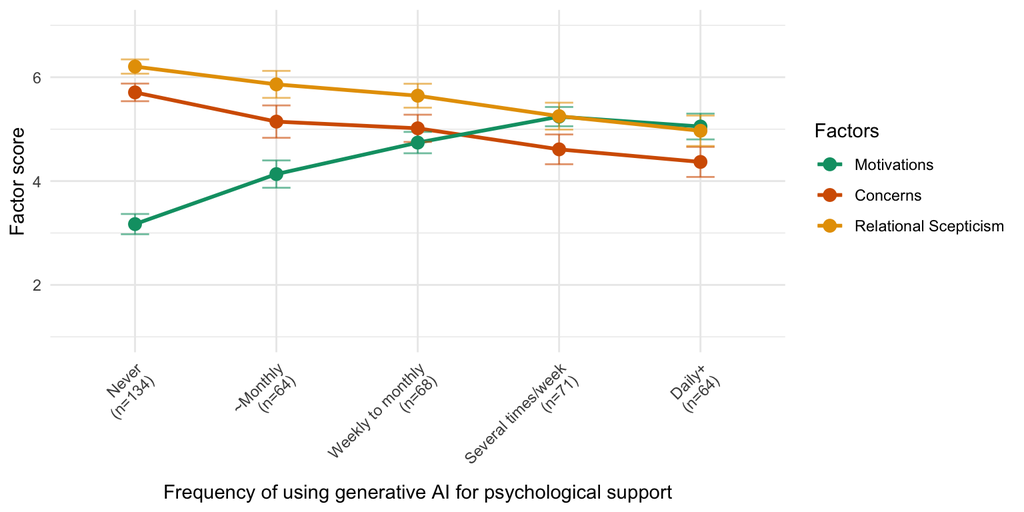

```r
freq_scores |>
  mutate(crit = qt(0.975, n - 1)) |>
  mutate(bracket_label = fct_inorder(paste0(frequency_level, "\n(n=", n, ")"))) |>
  ggplot(aes(x = bracket_label, y = mean_score, color = scale, group = scale)) +
  geom_line(linewidth = 1) +
  geom_errorbar(aes(ymin = mean_score - crit * se,
                    ymax = mean_score + crit * se),
                width = 0.2, alpha = 0.6) +
  geom_point(size = 3) +
  scale_colour_manual(
    name   = "Factors",
    breaks = c("motivations_score", "concerns_score", "rel_scept_score"),
    values = c(
      "motivations_score" = "#009E73",
      "concerns_score" = "#D55E00", "rel_scept_score" = "#E69F00"
    ),
    labels = c(
      "motivations_score" = "Motivations",
      "concerns_score" = "Concerns",
      "rel_scept_score" = "Relational Scepticism"
    )
  ) +
  scale_y_continuous(limits = c(1, 7)) +
  labs(x = "Frequency of using generative AI for psychological support", y = "Factor score", color = "") +
  theme_minimal() +
  theme(axis.text.x = element_text(angle = 45, hjust = 1))
```

```r
freq_scores_wide <- freq_scores |>
  pivot_wider(
    id_cols = c(frequency_level, n),
    names_from = scale,
    values_from = mean_score
  ) |>
  mutate(gap = motivations_score - concerns_score)

freq_scores_wide |> kable(digits = 2)
```

| frequency_level | n | concerns_score | motivations_score | rel_scept_score | gap |
| --- | --- | --- | --- | --- | --- |
| Never | 134 | 5.71 | 3.17 | 6.21 | -2.54 |
| ~Monthly | 64 | 5.15 | 4.13 | 5.86 | -1.01 |
| Weekly to monthly | 68 | 5.02 | 4.74 | 5.64 | -0.28 |
| Several times/week | 71 | 4.61 | 5.24 | 5.25 | 0.63 |
| Daily+ | 64 | 4.37 | 5.05 | 4.97 | 0.68 |

```r
freq_scores_wide <- freq_scores_wide |>
  mutate(
    trust_delta = motivations_score - lag(motivations_score),
    rv_delta = concerns_score - lag(concerns_score),
    rs_delta = rel_scept_score - lag(rel_scept_score)
  )

freq_level_labels <- freq_levels

bind_rows(
  freq_scores_wide |>
    select(frequency_level, trust_delta, rv_delta, rs_delta) |>
    mutate(
      comparison = case_when(
        row_number() == 2 ~ "Monthly - Never",
        row_number() == 3 ~ "Weekly - Monthly",
        row_number() == 4 ~ "Several x week - Weekly",
        row_number() == 5 ~ "Daily - Seveal x week"
      )
    ) |>
    filter(!is.na(trust_delta)) |>
    select(comparison, trust_delta, rv_delta, rs_delta),
  tibble(
    comparison = "Daily vs Never",
    trust_delta = freq_scores_wide$motivations_score[5] - freq_scores_wide$motivations_score[1],
    rv_delta = freq_scores_wide$concerns_score[5] - freq_scores_wide$concerns_score[1],
    rs_delta = freq_scores_wide$rel_scept_score[5] - freq_scores_wide$rel_scept_score[1]
  )
) |> kable(digits = 2,)
```

| comparison | trust_delta | rv_delta | rs_delta |
| --- | --- | --- | --- |
| Monthly - Never | 0.96 | -0.56 | -0.34 |
| Weekly - Monthly | 0.61 | -0.13 | -0.22 |
| Several x week - Weekly | 0.50 | -0.40 | -0.39 |
| Daily - Seveal x week | -0.19 | -0.24 | -0.28 |
| Daily vs Never | 1.88 | -1.34 | -1.24 |

## Platform use

We also explore whether users of different platforms for psychological support score differently on the TPSai subscales. This is an exploratory analysis and we do not have any specific pre-registered expectations.

```r
common_platforms <- eval_data |>
  count(platform) |>
  filter(n >= 5) |>
  pull(platform)

eval_data |>
  filter(platform %in% common_platforms) |>
  group_by(platform) |>
  summarise(n = n(),
            trust = mean(motivations_score),
            risk_vigilance = mean(concerns_score),
            relational_scepticism = mean(rel_scept_score),
            ) |>
  arrange(desc(n)) |>
  kable(digits = 2)
```

| platform | n | trust | risk_vigilance | relational_scepticism |
| --- | --- | --- | --- | --- |
| ChatGPT | 236 | 4.38 | 5.05 | 5.62 |
| Google Gemini | 85 | 4.04 | 5.24 | 5.78 |
| Microsoft Copilot | 41 | 3.66 | 5.52 | 6.14 |
| Claude | 26 | 4.59 | 4.68 | 5.47 |

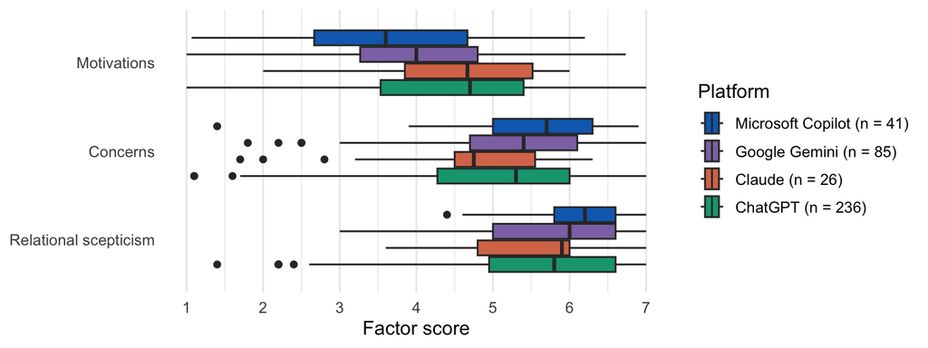

```r
brand <- c(
  "ChatGPT"           = "#10A37F",  # OpenAI green
  "Claude"            = "#D97757",  # Anthropic clay
  "Google Gemini"     = "#8E75B2",  # Gemini purple
  "Microsoft Copilot" = "#0F6CBD"   # Fluent blue
)

plot_data <- eval_data |>
  filter(platform %in% common_platforms) |>
  add_count(platform) |>
  pivot_longer(
    cols      = c(motivations_score, concerns_score, rel_scept_score),
    names_to  = "scale",
    values_to = "score"
  ) |>
  mutate(
    scale = factor(
      scale,
      levels = c("rel_scept_score", "concerns_score", "motivations_score"),
      labels = c("Relational scepticism", "Concerns", "Motivations")
    )
  )

n_lab <- plot_data |> distinct(platform, n) |> tibble::deframe()

ggplot(plot_data, aes(x = score, y = scale, fill = platform)) +
  geom_boxplot(colour = "grey20", varwidth = FALSE) +
  scale_fill_manual(
    values = brand,
    labels = \(x) paste0(x, " (n = ", n_lab[x], ")")
  ) +
  scale_x_continuous(breaks = 1:7, limits = c(1, 7)) +
  guides(fill = guide_legend(reverse = TRUE)) +
  labs(
    x    = "Factor score",
    y    = NULL,
    fill = "Platform"
  ) +
  theme_minimal(base_size = 12) +
  theme(
    panel.grid.major.y = element_blank(),
    legend.position    = "right"
  )
```

## Age

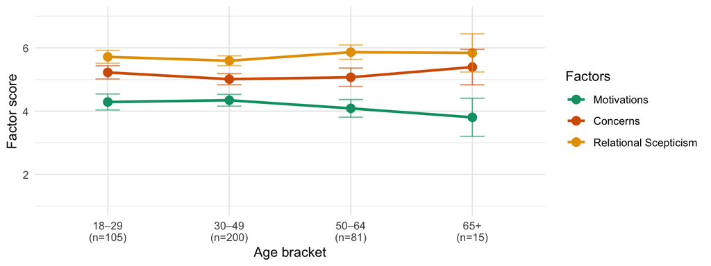

```r
schemes <- list(
  pew      = list(breaks = c(18, 30, 50, 65, Inf),
                  labels = c("18–29", "30–49", "50–64", "65+")),
  ofcom    = list(breaks = c(18, 25, 35, 45, 55, 65, 75, Inf),
                  labels = c("18–24","25–34","35–44","45–54","55–64","65–74","75+")),
  lifespan = list(breaks = c(18, 26, 40, 65, Inf),
                  labels = c("18–25", "26–39", "40–64", "65+")),
  mh       = list(breaks = c(18, 25, 35, 50, 65, Inf),
                  labels = c("18–24", "25–34", "35–49", "50–64", "65+"))
)
scheme <- schemes$pew

dat <- eval_data |>
  mutate(Age = as.integer(Age),
         age_bracket = cut(Age, breaks = scheme$breaks,
                           labels = scheme$labels, right = FALSE)) |>
  filter(!is.na(age_bracket))

bracket_n <- count(dat, age_bracket, name = "n_bracket", .drop = FALSE)

plot_df <- dat |>
  pivot_longer(c(motivations_score, concerns_score, rel_scept_score),
               names_to = "scale", values_to = "score") |>
  filter(!is.na(score)) |>
  group_by(age_bracket, scale) |>
  summarise(mean_score = mean(score),
            se = sd(score) / sqrt(n()),
            n_cell = n(), .groups = "drop") |>
  mutate(crit = qt(0.975, n_cell - 1)) |>
  left_join(bracket_n, by = "age_bracket") |>
  mutate(age_bracket_label = factor(
    paste0(age_bracket, "\n(n=", n_bracket, ")"),
    levels = paste0(bracket_n$age_bracket, "\n(n=", bracket_n$n_bracket, ")")))

ggplot(plot_df, aes(age_bracket_label, mean_score,
                    colour = scale, group = scale)) +
  geom_line(linewidth = 1) +
  geom_point(size = 3) +
  geom_errorbar(aes(ymin = mean_score - crit * se,
                    ymax = mean_score + crit * se),
                width = 0.2, alpha = 0.6) +
  coord_cartesian(ylim = c(1, 7)) +
  scale_colour_manual(
    name = "Factors",
    breaks = c("motivations_score", "concerns_score", "rel_scept_score"),
    values = c(motivations_score = "#009E73", concerns_score = "#D55E00",
               rel_scept_score = "#E69F00"),
    labels = c(motivations_score = "Motivations", concerns_score = "Concerns",
               rel_scept_score = "Relational Scepticism")) +
  labs(x = "Age bracket", y = "Factor score") +
  theme_minimal()
```

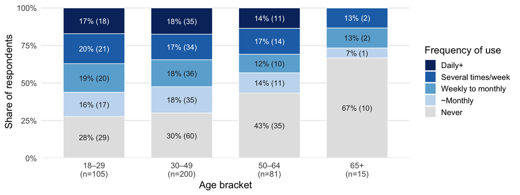

```r
library(scales)

freq_short <- c(
  "Never",
  "~Monthly",
  "Weekly to monthly",
  "Several times/week",
  "Daily+"
)

freq_full <- c(
  "Never",
  "About once a month",
  "About once a week to a few times a month",
  "Several times a week",
  "Daily or multiple times a day"
)

# Intensity ramp: grey = no use, then light -> dark with increasing frequency
fill_cols <- c(
  "Never"              = "#E3E3E3",
  "~Monthly"           = "#C6DBEF",
  "Weekly to monthly"  = "#6BAED6",
  "Several times/week" = "#2171B5",
  "Daily+"             = "#08306B"
)

scheme <- list(
  breaks = c(18, 30, 50, 65, Inf),
  labels = c("18–29", "30–49", "50–64", "65+")
)


plot_df <- eval_data |>
  mutate(
    Age = as.integer(Age),
    age_bracket = cut(Age, breaks = scheme$breaks, labels = scheme$labels,
                      right = FALSE),
    frequency = factor(frequency_level, levels = 1:5, labels = freq_short)
  ) |>
  filter(!is.na(age_bracket), !is.na(frequency)) |>
  count(age_bracket, frequency, .drop = FALSE) |>
  group_by(age_bracket) |>
  mutate(prop = n / sum(n), n_bracket = sum(n)) |>
  ungroup() |>
  mutate(
    bracket_label = factor(
      paste0(age_bracket, "\n(n=", n_bracket, ")"),
      levels = unique(paste0(age_bracket, "\n(n=", n_bracket, ")")[order(age_bracket)])
    ),
    lab_col  = if_else(frequency %in% c("Several times/week", "Daily+"),
                       "white", "grey15"),
    lab_text = if_else(prop >= 0.06,
                       paste0(percent(prop, accuracy = 1), " (", n, ")"), "")
  )


ggplot(plot_df, aes(bracket_label, prop, fill = frequency)) +
  geom_col(width = 0.7, colour = "white", linewidth = 0.3,
           position = position_stack(reverse = TRUE)) +
  geom_text(aes(label = lab_text, colour = lab_col),
            position = position_stack(vjust = 0.5, reverse = TRUE),
            size = 2.9, lineheight = 0.95, show.legend = FALSE) +
  scale_colour_identity() +
  scale_fill_manual(values = fill_cols, name = "Frequency of use") +
  scale_y_continuous(labels = percent, expand = expansion(c(0, 0.02))) +
  labs(x = "Age bracket", y = "Share of respondents") +
  theme_minimal(base_size = 11) +
  theme(
    panel.grid.major.x = element_blank(),
    panel.grid.minor   = element_blank(),
    legend.position    = "right",
    legend.key.size    = unit(0.9, "lines")
  ) +
  guides(fill = guide_legend(ncol = 1, reverse = TRUE))
```

## Psychotherapy

Questions we asked in the survey:

1. How often have you attended psychotherapy or counselling sessions in your lifetime?
   1. Never
   2. Once or a few sessions only (1–5 sessions)
   3. A short course (roughly 6–20 sessions)
   4. An extended course (roughly 21–50 sessions)
   5. Long-term or ongoing therapy (more than 50 sessions)
2. Thinking about your overall experience of psychotherapy or counselling, how satisfied have you been with it?
   1. Very dissatisfied
   2. Dissatisfied
   3. Neutral
   4. Satisfied
   5. Very satisfied

**Analysis:** plot scale scores across the levels of both Q1 and Q2, checking for any trends and substantial differences between levels. Exploratory analysis with no pre-registered hypothesis.

```r
plot_psy <- function(data, var, xlab) {
  data |>
    filter(!is.na({{ var }})) |>
    pivot_longer(c(motivations_score, concerns_score, rel_scept_score),
                 names_to = "scale", values_to = "score") |>
    group_by({{ var }}, scale) |>
    summarise(mean_score = mean(score),
              se = sd(score) / sqrt(n()),
              n  = n(), .groups = "drop") |>
    mutate(label = paste0({{ var }}, "\n(n=", n, ")")) |>
    ggplot(aes(x = label, y = mean_score, colour = scale, group = scale)) +
    geom_point(size = 2) +
    geom_line(linewidth = 1) +
    geom_errorbar(aes(ymin = mean_score - 1.96 * se,
                      ymax = mean_score + 1.96 * se),
                  width = 0.2, alpha = 0.6) +
    scale_y_continuous(limits = c(1, 7)) +
    labs(x = xlab, y = "Scale score", colour = "Scale") +
    theme_minimal() +
    theme(axis.text.x = element_text(angle = 45, hjust = 1))
}
```

**Lifetime psychotherapy exposure**

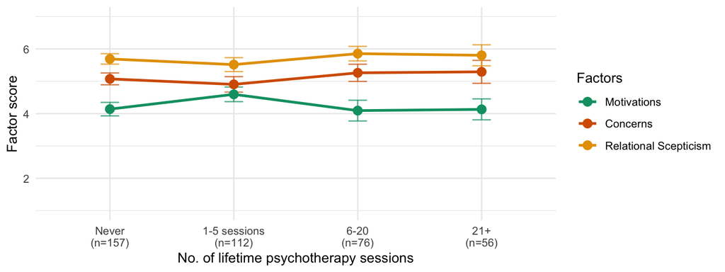

```r
psy_freq_levels <- c(
  "Never",
  "Once or a few sessions only (1–5 sessions)",
  "A short course (roughly 6–20 sessions)",
  "An extended course (roughly 21–50 sessions)",
  "Long-term or ongoing therapy (more than 50 sessions)"
)

psy_freq_labels <- c(
  "Never", "1-5 sessions", "6-20", "21-50", "50+"
)

psy_freq_data <- eval_data |>
  mutate(
    psy_freq = factor(`PSY-FREQ`, levels = psy_freq_levels,
                      labels = psy_freq_labels),
    psy_freq = fct_collapse(psy_freq, "21+" = c("21-50", "50+")),
    psy_freq = factor(psy_freq,
                      levels = c("Never", "1-5 sessions", "6-20", "21+"))
  ) |>
  filter(!is.na(psy_freq))

# respondent-level n per exposure level (not per cell)
freq_n <- count(psy_freq_data, psy_freq, name = "n_group", .drop = FALSE)

plot_df <- psy_freq_data |>
  pivot_longer(c(motivations_score, concerns_score, rel_scept_score),
               names_to = "scale", values_to = "score") |>
  filter(!is.na(score)) |>
  group_by(psy_freq, scale) |>
  summarise(mean_score = mean(score),
            se = sd(score) / sqrt(n()),
            n_cell = n(), .groups = "drop") |>
  mutate(crit = qt(0.975, n_cell - 1)) |>
  left_join(freq_n, by = "psy_freq") |>
  mutate(x_label = factor(
    paste0(psy_freq, "\n(n=", n_group, ")"),
    levels = paste0(freq_n$psy_freq, "\n(n=", freq_n$n_group, ")")))


ggplot(plot_df, aes(x_label, mean_score, colour = scale, group = scale)) +
  geom_line(linewidth = 1) +
  geom_errorbar(aes(ymin = mean_score - crit * se,
                    ymax = mean_score + crit * se),
                width = 0.15, alpha = 0.7) +
  geom_point(size = 3) +
  coord_cartesian(ylim = c(1, 7)) +
  scale_colour_manual(
    name = "Factors",
    breaks = c("motivations_score", "concerns_score", "rel_scept_score"),
    values = c(motivations_score = "#009E73", concerns_score = "#D55E00",
               rel_scept_score = "#E69F00"),
    labels = c(motivations_score = "Motivations", concerns_score = "Concerns",
               rel_scept_score = "Relational Scepticism")) +
  labs(x = "No. of lifetime psychotherapy sessions",
       y = "Factor score") +
  theme_minimal(base_size = 11) +
  theme(axis.text.x = element_text(hjust = 0.5))
```

**Psychotherapy satisfaction**

```r
psy_sat_levels <- c(
  "Very dissatisfied",
  "Dissatisfied",
  "Neutral",
  "Satisfied",
  "Very satisfied"
)

psy_sat_data <- eval_data |>
  filter(!is.na(`PSY-SAT`)) |>
  mutate(psy_sat = factor(`PSY-SAT`, levels=psy_sat_levels, ordered=TRUE)) |>
  pivot_longer(cols = c(motivations_score, concerns_score, rel_scept_score),
               names_to = "scale", values_to = "score") |>
  group_by(psy_sat, scale) |>
  summarise(mean_score = mean(score),
            se = sd(score) / sqrt(n()),
            n  = n(), .groups = "drop")
```

```r
psy_sat_data |>
  pivot_wider(
    id_cols = c(psy_sat, n),
    names_from = scale,
    values_from = mean_score
  ) |> kable(digits = 2)
```

| psy_sat | n | concerns_score | motivations_score | rel_scept_score |
| --- | --- | --- | --- | --- |
| Very dissatisfied | 15 | 4.53 | 4.49 | 5.32 |
| Dissatisfied | 48 | 5.45 | 4.32 | 6.01 |
| Neutral | 48 | 4.66 | 4.58 | 5.13 |
| Satisfied | 102 | 5.11 | 4.26 | 5.73 |
| Very satisfied | 31 | 5.51 | 4.13 | 6.09 |

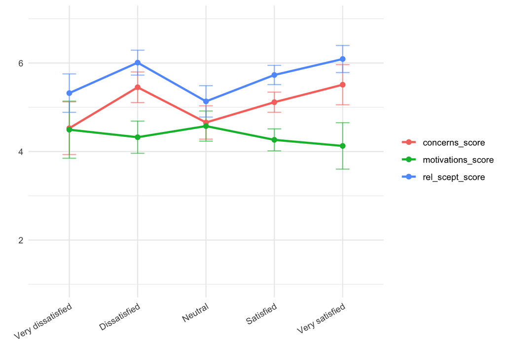

```r
psy_sat_data |> ggplot(aes(x = psy_sat, y = mean_score, color = scale, group = scale)) +
  geom_line(linewidth = 1) +
  geom_errorbar(aes(ymin = mean_score - 1.96 * se,
                    ymax = mean_score + 1.96 * se),
                width = 0.2, alpha = 0.6) +
  geom_point(size = 2) +
  scale_y_continuous(limits = c(1, 7)) +
  labs(x = "", y = "", color = "") +
  theme_minimal() +
  theme(axis.text.x = element_text(angle = 30, hjust = 1))
```

## References

Campbell, Chloe, Michal Tanzer, Rob Saunders, et al. 2021. “Development and Validation of a Self-Report Measure of Epistemic Trust.” *PLOS ONE* 16 (4): e0250264. https://doi.org/10.1371/journal.pone.0250264.

Merritt, Stephanie M., Heather Heimbaugh, Jennifer LaChapell, and Deborah Lee. 2013. “I Trust It, but i Don’t Know Why: Effects of Implicit Attitudes Toward Automation on Trust in an Automated System.” *Human Factors* 55 (3): 520–34. https://doi.org/10.1177/0018720812465081.

Ragone, Grazia, Paolo Buono, Judith Good, and Rosa Lanzilotti. 2026. “Do Children Trust AI, and Should They? Designing and Validating a Child-Centred k-AI Trust Scale for Intelligent Systems.” (New York, NY, USA), CHI ’26, April 13, 118. https://doi.org/10.1145/3772318.3790765.

Scholz, David D., Johannes Kraus, and Linda Miller. 2025. “Measuring the Propensity to Trust in Automated Technology: Examining Similarities to Dispositional Trust in Other Humans and Validation of the PTT-a Scale.” *International Journal of HumanComputer Interaction* 41 (2): 970–93. https://doi.org/10.1080/10447318.2024.2307691.